# Project 1 - Stroop Test

## Abstract

This Jupter notebook will examine the results of the Stroop Test. The Stroop test measures the reaction time if interference in present in a task. In this particular test the subject needs to read or say the color of the word, when the color or text is conlflicting.

### What is our independent and dependent variable?

In this test the independent variables are the subjects and the congruent and incongruent word display. The dependent variable is the time it takes to name the ink variables

### Hypothesis

Given an equal set length of congruent and incongruent words the time to average time to name the ink colors is not significantly different.

$$ \mu_{c} = \text{Average time to read ink color for congruent words} \\ \mu_{i} = \text{Average time to read ink color for incongruent words} \\ H_{O}: \mu_{c} - \mu_{i} = 0 \\ H_{A}: \mu_{c} - \mu_{i} \neq 0 $$

### Expected test

Since the same subject performs both portions of the Stroop test the hypothesis will be tested using a paired T test. The congruent and incongruent portions of the test are independent, as it is assumed that the subjects ability reading or color recognition is not affected by the experiments.

A two sample two sided test of significance is appropriate as the difference between the means is being tested but not the direction in which they're different. The level of significance chosen is 5%, as it is a standard choice in many academic papers.

### Load Data

```python
import os
import pandas as pd
import numpy as np
path = r'data/stroopdata.csv'
```

```python
df = pd.read_csv(path)
df.head()
```

|  | Congruent | Incongruent |
| --- | --- | --- |
| 0 | 12.079 | 19.278 |
| 1 | 16.791 | 18.741 |
| 2 | 9.564 | 21.214 |
| 3 | 8.630 | 15.687 |
| 4 | 14.669 | 22.803 |

### Descriptive Statistics

Making an initial assumption that the data is normally distributed we'll take the mean and standard deviation

```python
df.describe()
```

|  | Congruent | Incongruent |
| --- | --- | --- |
| count | 24.000000 | 24.000000 |
| mean | 14.051125 | 22.015917 |
| std | 3.559358 | 4.797057 |
| min | 8.630000 | 15.687000 |
| 25% | 11.895250 | 18.716750 |
| 50% | 14.356500 | 21.017500 |
| 75% | 16.200750 | 24.051500 |
| max | 22.328000 | 35.255000 |

### Observations

We can see that the means are different between the two samples, as well as the standard deviation. For both measures the incogruent sample has a larger spread and mean as intuition would suggest. We will look into the samples below, as well as test our hypothesis using a paired T Test.

### Visualizations

For both datasets the assumption of normality will be checked using a histogram

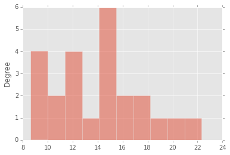

```python
import matplotlib
%matplotlib inline
matplotlib.style.use('ggplot')
df["Congruent"].plot(kind='hist', alpha = .5)
```

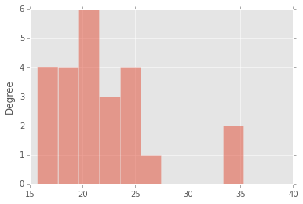

```python
df["Incongruent"].plot(kind='hist', alpha = .5)
```

### Test for Significance in the difference between the means

To evaluate the difference between the two distributions, a paired T Test was performed. The paired T test was used as the subjects performed both the congruent and incongruent part of the test. As the results show below, the difference between the means is significant and much less likely than the 5% two tailed significance level assumed for this experiment. The probability of the means being the same is approximately 0%.

With this evidence we reject the null hypothesis that the mean time to read through both the congruent and incongruent word combinations is the same.

This matches my expectations as I struggled greatly with the Stroop Test when performing it myself.

```python
from scipy import stats
stats.ttest_rel(df["Congruent"], df["Incongruent"])
```

```
Ttest_relResult(statistic=-8.020706944109957, pvalue=4.1030005857111781e-08)
```

### Causes and Additional tests

Further research suggests why the incongruent test is more difficult than the congrouent test. In a very simplified explanation, essentially the brain is competing against itself, in this particular case the word processing center against the visual processing center. From other studies, it seems to be reported that people with brain injuries or other mental handicaps exihibit and even greater Stroop Effect.

It also seems that researchers have also used this Stroop Effect to measure the effects of depression, spatial perception, and numerical interpretation, using a similar test.

### Sources

https://en.wikipedia.org/wiki/Stroop_effect https://faculty.washington.edu/chudler/words.html